# Chapter 6 The Standard Trade Model

# Preview

- Relative supply and relative demand
- The terms of trade and welfare
- Effects of economic growth, import tariffs, and export subsidies
- International borrowing and lending

# A Standard Model of a Trading Economy

# Introduction

- Standard trade model is a general model that includes Ricardian, specific factors, and Heckscher-Ohlin models as special cases.
  - Two goods, food (F) and cloth (C).
  - Each country’s PPF is a smooth curve.

# Introduction

- Differences in *labor services, labor skills, physical capital, land, and technology* between countries cause differences in production possibility frontiers.
- A country’s PPF determines its relative supply function.
- National relative supply functions determine a world relative supply function, which along with world relative demand determines the equilibrium under international trade.

# Production Possibilities and Relative Supply

- What a country produces depends on the relative price of cloth to food $P_C/P_F$.
- An economy chooses its production of cloth $Q_C$ and food $Q_F$ to maximize the value of its output $V = P_C Q_C + P_F Q_F$, given the prices of cloth and food.
  - The slope of an isovalue line equals – ($P_C/P_F$)
  - Produce at point where PPF is tangent to isovalue line.

# RP Determine the Economy’s Output

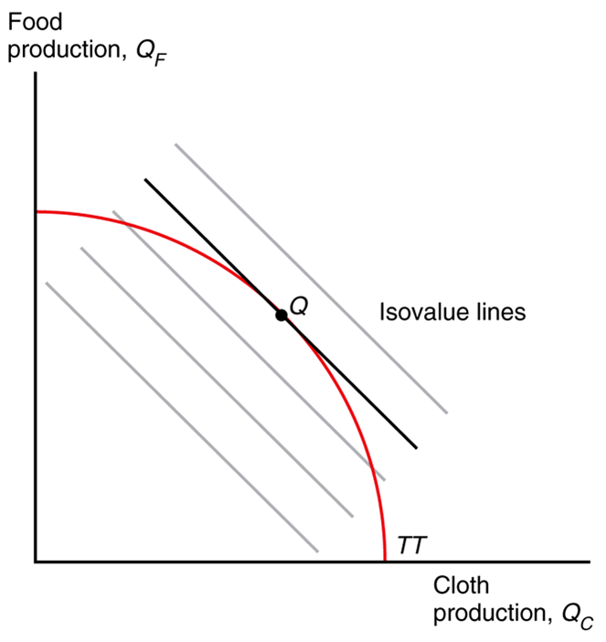

# Production Possibilities and Relative Supply

- Relative prices and relative supply:
  - An increase in the price of cloth relative to food $P_C/P_F$ makes the isovalue line steeper.
  - Production shifts from point $Q^1$ to point $Q^2$.
  - Supply of cloth relative to food $Q_C/Q_F$ rises.
  - Relative supply of cloth to food increases with the relative price of cloth to food.

# How an Increase in the RP of Cloth Affects RS

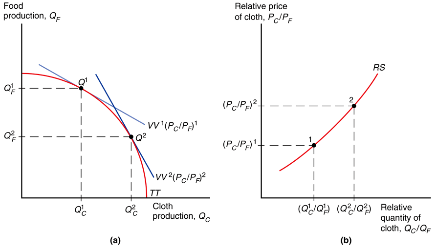

# Relative Prices and Demand

- The value of the economy’s consumption must equal the value of the economy’s production. $P_C D_C + P_F D_F = P_C Q_C + P_F Q_F = V$
- Assume that the economy’s consumption decisions may be represented as if they were based on the tastes of a single representative consumer.
- An **indifference curve** represents combinations of cloth and food that leave the consumer equally well off (indifferent).

# Relative Prices and Demand

- Indifference curves
  - are downward sloping – if you have less cloth, then you must have more food to be equally satisfied.
  - that lie farther from the origin make consumers more satisfied – they prefer having more of both goods.
  - become flatter when they move to the right – with more cloth and less food, an extra yard of cloth becomes less valuable in terms of how many calories of food you are willing to give up for it.

# Relative Prices and Demand

- Consumption choice is based on preferences and relative price of goods:
  - Consume at point D where the isovalue line is tangent to the indifference curve.
- Economy exports cloth – the quantity of cloth produced exceeds the quantity of cloth consumed – and imports food.

# Production, Consumption, and Trade in the Standard Model

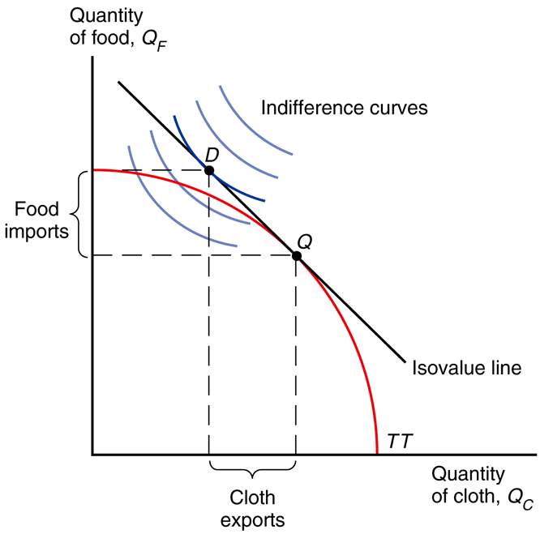

# Relative Prices and Demand

- Relative prices and relative demand
  - An increase in the relative price of cloth $P_C/P_F$ causes consumption choice to shift from point $D^1$ to point $D^2$.
  - Demand for cloth relative to food $D_C/D_F$ falls.
  - Relative demand for cloth to food falls as the relative price of cloth to food rises.

# Relative Prices and Demand

- An economy that exports cloth is better off when the price of cloth rises relative to the price of food:
  - the isovalue line becomes steeper and a higher indifference curve can be reached.
- A higher relative price of cloth means that more calories of food can be imported for every yard of cloth exported.

# Relative Prices and Demand

- If the economy cannot trade:
  - The relative price of cloth to food is determined by the intersection of relative demand and relative supply for that country.
  - Consume and produce at point $D^3$ where the indifference curve is tangent to the production possibilities frontier.

# Effects of a Rise in the RP of Cloth and Gains from Trade

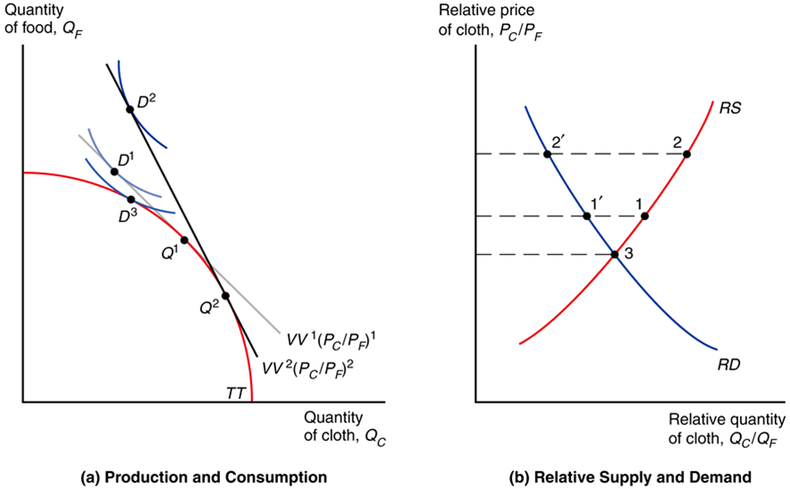

# The Welfare Effects of Changes in the Terms of Trade

- The **terms of trade** refers to the price of exports relative to the price of imports.
  - When a country exports cloth and the relative price of cloth increases, the terms of trade rise.
- Because a higher relative price for exports means that the country can afford to buy more imports, an increase in the terms of trade increases a country’s welfare.
- A decline in the terms of trade decreases a country’s welfare.

# Determining Relative Prices

- To determine the price of cloth relative to the price food, use relative supply and relative demand.
  - *World* supply of cloth relative to food at each relative price.
  - *World* demand for cloth relative to food at each relative price.
  - World quantities are the sum of quantities from the two countries in the world: $(Q_C + Q_C^*)/(Q_F + Q_F^*)$ and $(D_C + D_C^*)/(D_F + D_F^*)$.

# Equilibrium RP with Trade and Associated Trade Flows

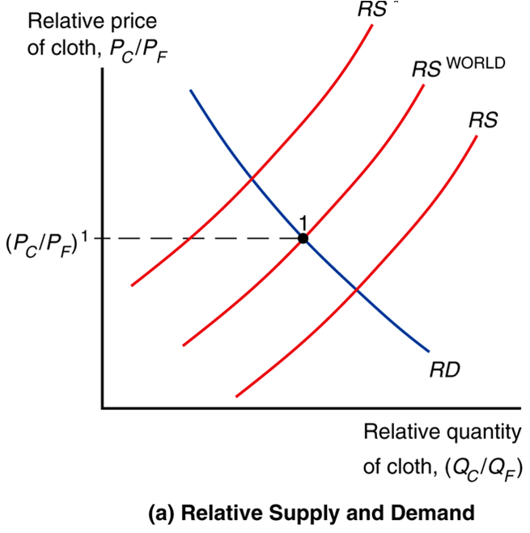

# Equilibrium RP with Trade and Associated Trade Flows

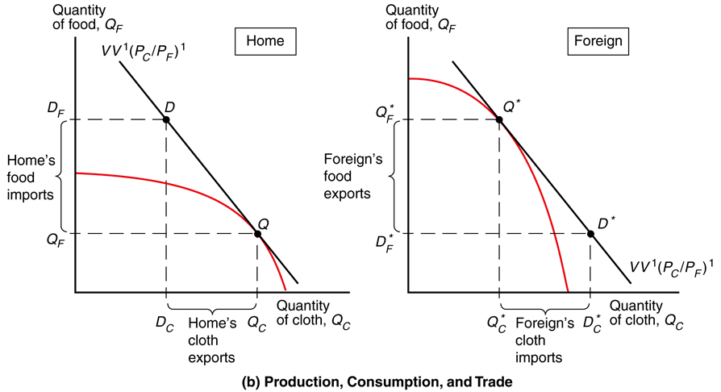

# The Effects of Economic Growth

- Is economic growth in China good for the standard of living in the U.S.?
- Is growth in a country more or less valuable when it is integrated in the world economy?
- The standard trade model gives us precise answers to these questions.

# The Effects of Economic Growth

- Growth is usually **biased**: it occurs in one sector more than others, causing relative supply to change.
  - Rapid growth has occurred in U.S. computer industries but relatively little growth has occurred in U.S. textile industries.
  - In the Ricardian model, technological progress in one sector causes biased growth.
  - In the Heckscher-Ohlin model, an increase in one factor of production causes biased growth.

# Biased Growth

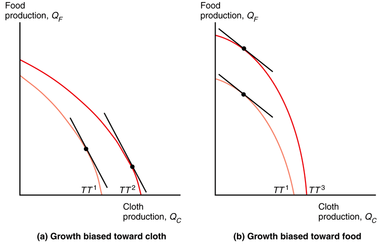

# Biased Growth

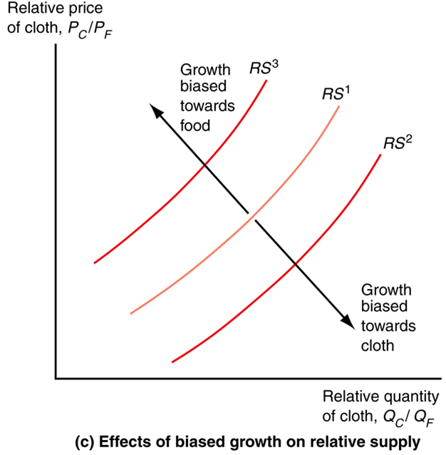

# The Effects of Economic Growth

- Biased growth and the resulting change in relative supply causes a change in the terms of trade.
  - Biased growth in the cloth industry (in either the home or foreign country) will lower the price of cloth relative to the price of food and lower the terms of trade for cloth exporters.
  - Biased growth in the food industry (in either the home or foreign country) will raise the price of cloth relative to the price of food and raise the terms of trade for cloth exporters.
  - Suppose that the home country exports cloth and imports food.

# Growth and World RS

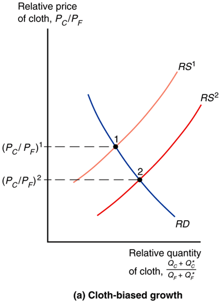

# Growth and World RS

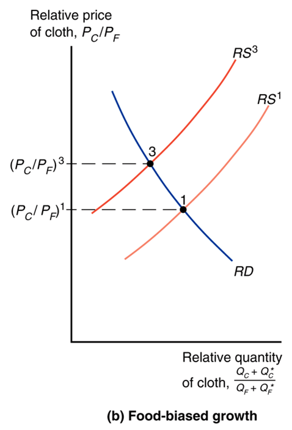

# The Effects of Economic Growth

- **Export-biased growth** is growth that expands a country’s production possibilities dispro-portionately in that country’s export sector.
  - Biased growth in the food industry in the foreign country is export-biased growth for the foreign country.
- **Import-biased growth** is growth that expands a country’s production possibilities dispro-portionately in that country’s import sector.
  - Biased growth in cloth production in the foreign country is import-biased growth for the foreign country.

# The Effects of Economic Growth

- Export-biased growth reduces a country’s terms of trade, reducing its welfare and increasing the welfare of foreign countries.
- Import-biased growth increases a country’s terms of trade, increasing its welfare and decreasing the welfare of foreign countries.

# Has Growth in Asia Reduced the Welfare of High-Income Countries?

- The standard trade model predicts that import-biased growth in China reduces the U.S. terms of trade and the standard of living in the U.S.
  - Import-biased growth for China would occur in sectors that compete with U.S. exports.

# Has Growth in Asia Reduced the Welfare of High-Income Countries?

- But this prediction is not supported by data: there should be negative changes in the terms of trade for the U.S. and other high-income countries.
  - In fact, changes in the terms of trade for high-income countries have been positive and negative for developing Asian countries.

# Average Annual Percent Changes in Terms of Trade for the United States and China

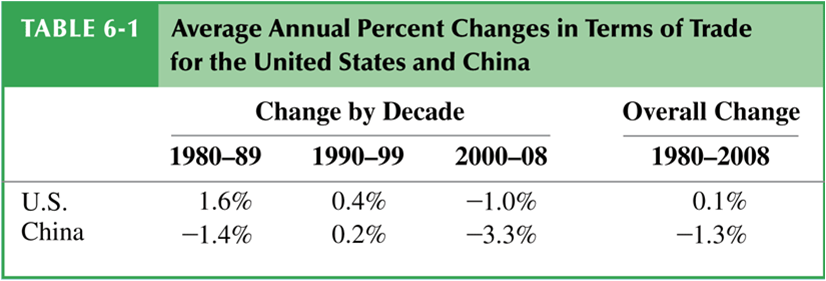

# Tariffs and Export Subsidies: Simultaneous Shifts in RS and RD

# Import Tariffs and Export Subsidies: Simultaneous Shifts in RS and RD

- **Import tariffs** are taxes levied on imports.
- **Export subsidies** are payments given to domestic producers that export.
- Both policies influence the terms of trade and therefore national welfare.
- Import tariffs and export subsidies drive a wedge between prices in world markets and prices in domestic markets.

# Relative Price and Supply Effects of a Tariff

- If the home country imposes a tariff on food imports, the price of food relative to the price of cloth rises for domestic consumers.
  - Likewise, the price of cloth relative to the price of food falls for domestic consumers.
  - Domestic producers will receive a lower relative price of cloth, and therefore will be more willing to switch to food production: relative supply of cloth will decrease.
  - Domestic consumers will pay a lower relative price for cloth, and therefore will be more willing to switch to cloth consumption: relative demand for cloth will increase.

# Effects of a Food Tariff on the Terms of Trade

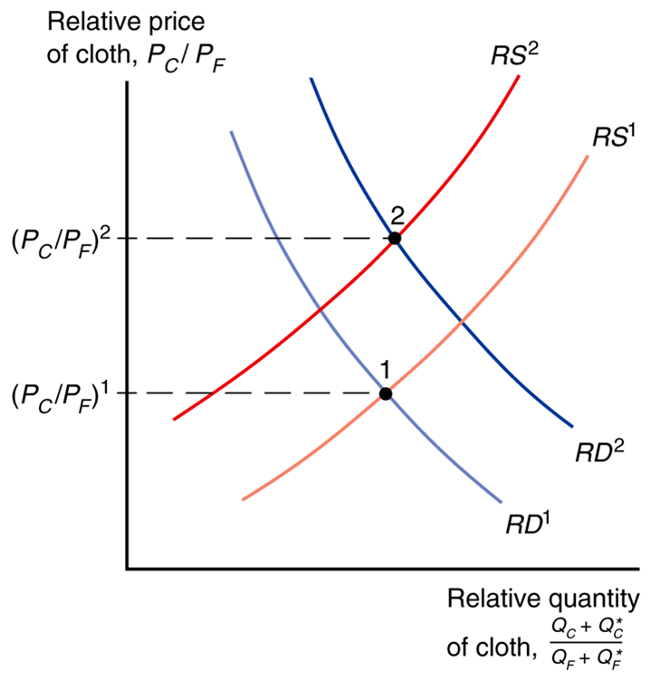

# Relative Price and Supply Effects of a Tariff

- When the home country imposes an import tariff, the terms of trade increase and the welfare of the country may increase.
- The magnitude of this effect depends on the size of the home country relative to the world economy.
  - If the country is a small part of the world economy, its tariff (or subsidy) policies will not have much effect on world relative supply and demand, and thus on the terms of trade.
  - But for large countries, a tariff may maximize national welfare at the expense of foreign countries.

# Effects of an Export Subsidy

- If the home country imposes a subsidy on cloth exports, the price of cloth relative to the price of food rises for domestic consumers.
  - Domestic producers will receive a higher relative price of cloth when they export, and therefore will be more willing to switch to cloth production: relative supply of cloth will increase.
  - Domestic consumers must pay a higher relative price of cloth to producers, and therefore will be more willing to switch to food consumption: relative demand for cloth will decrease.

# Effects of a Cloth Subsidy on the Terms of Trade

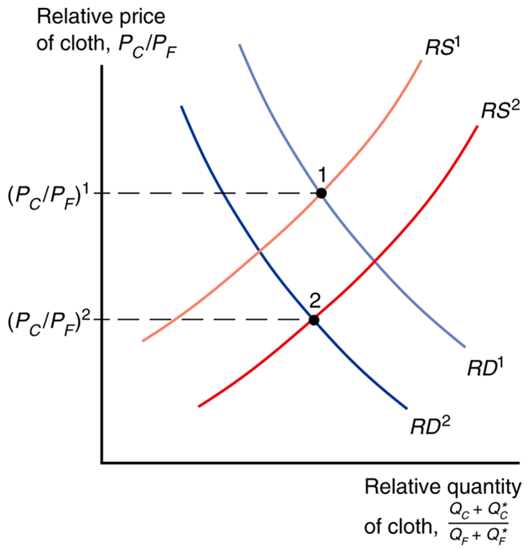

# Effects of an Export Subsidy

- When the home country imposes an export subsidy, the terms of trade decrease and the welfare of the country decreases to the benefit of the foreign country.

# Implications of Terms of Trade Effects: Who Gains and Who Loses?

- The standard trade model predicts that
  - an import tariff by the home country can increase domestic welfare at the expense of the foreign country.
  - an export subsidy by the home country reduces domestic welfare to the benefit of the foreign country.

# Implications of ToT Effects: Who Gains and Who Loses?

- Additional effects of tariffs and subsidies that can occur in a world with many countries and many goods:
  - A foreign country may subsidize the export of a good that the U.S. also exports, which will reduce the price for the U.S. in world markets and decrease its terms of trade.
    - The EU subsidizes agricultural exports, which reduce the price that American farmers receive for their goods in world markets.
  - A foreign country may put a tariff on an imported good that the U.S. also imports, which will reduce the price for the U.S. in world markets and increase its terms of trade.

# Implications of Terms of Trade Effects: Who Gains and Who Loses?

- Export subsidies by foreign countries on goods that
  - the U.S. imports *reduce the world price of U.S. imports* and increase the terms of trade for the U.S.
  - the U.S. also exports *reduce the world price of U.S. exports* and decrease the terms of trade for the U.S.
- Import tariffs by foreign countries on goods that
  - the U.S. exports *reduce the world price of U.S. exports* and decrease the terms of trade for the U.S.
  - the U.S. also imports *reduce the world price of U.S. imports* and increase the terms of trade for the U.S.

# Implications of Terms of Trade Effects: Who Gains and Who Loses?

- Export subsidies on a good *decrease the relative world price* of that good by increasing relative supply of that good and decreasing relative demand of that good.
- Import tariffs on a good *decrease the relative world price* of that good (and increase the relative world price of other goods) by increasing the relative supply of that good and decreasing the relative demand of that good.

# International Borrowing and Lending

# International Borrowing and Lending

- The standard trade model can be modified to analyze international borrowing and lending.
  - Two goods are current and future consumption (same good at different times), rather than different goods at the same time.
- Countries usually have different opportunities to invest to become able to produce more in the future.
- A special kind of production possibility frontier, an **intertemporal production possibility frontier**, depicts different possible combinations of current output and future output.

# The Intertemporal PPF

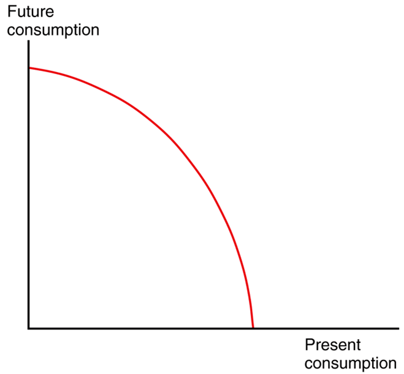

# International Borrowing and Lending

- Suppose that Home has production possibilities biased towards current output, while Foreign has production possibilities biased towards future output.
  - Foreign has better opportunities to invest now to generate more output in the future.

# International Borrowing and Lending

- If you borrow 1 unit of output, you must repay principal + interest = 1 + r in the future, where r is the **real interest rate**.
- The price of future consumption relative to current consumption is 1/(1+r).
  - 1 unit of current consumption is worth 1 + r of future consumption,
    - so 1 unit of future consumption is worth 1/(1 + r) units of current consumption.

# International Borrowing and Lending

- Home exports current consumption and imports future consumption.
- Home lends to Foreign by consuming less than it produces now.
- Foreign pays back the loan by consuming less than it produces in the future.

# International Borrowing and Lending

- When international borrowing and lending are allowed, the relative price of future consumption – and thus the world real interest rate - is determined by the intersection of world relative demand and world relative supply.

# Equilibrium Interest Rate with Borrowing and Lending

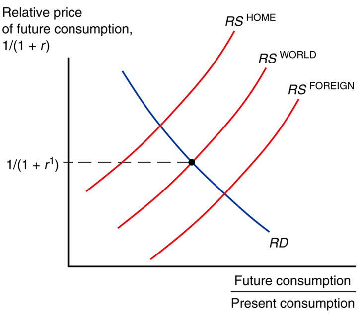

# Summary

# Summary

1. The terms of trade refers to the price of exports relative to the price of imports.
2. Export-biased growth reduces a country’s terms of trade, reducing its welfare and increasing the welfare of foreign countries.
3. Import-biased growth increases a country’s terms of trade, increasing its welfare and decreasing the welfare of foreign countries.
4. When a country imposes an import tariff, its terms of trade increase and its welfare may increase.

# Summary

5. When a country imposes an export subsidy, its terms of trade decrease and its welfare decreases.
6. International borrowing and lending is intertemporal trade, where countries with profitable investment opportunities borrow funds today and repay lenders in the future, benefiting both borrowers and lenders.
7. The price of future consumption relative to the price of current consumption, 1/(1 + r), is determined like any other relative price.